# DS 4635 Homework 1

Aidan Horn

3/21/2022

## Section 2.4, page 52, question 1

1. For each of parts (a) through (d), indicate whether we would generally expect the performance of a flexible statistical learning method to be better or worse than an inflexible method. Justify your answer.
1. The sample size n is extremely large, and the number of predictors p is small.
- **With a large sample size and a small number of predictors, we can expect that a more flexible statistical model will perform better. A lower number of predictors means that a flexbile model can better capture a trend by incorporating more functions without overfitting a small number of observations.**
2. The number of predictors p is extremely large, and the number of observations n is small.
- **A flexible model will perform worse when p is large and n is small since a flexible model will tend to overfit a small number of samples, producing a high testing MSE despite a low training MSE**
3. The relationship between the predictors and response is highly non-linear.
- **A flexible model may incorporate non-linear transofrmations of the data into the model making it much better at fitting to non-linear relationships than an inflexible model**
4. The variance of the error terms, i.e. σ2 = Var(ϵ), is extremely high.
- **An inflexible model would perform better than a flexible model since a high variance would indicate that there is not enough correlation between the data to make complicated inferences with much accuracy. It would be better to use an inflexible, linear fit to capture the most basic trends.**

## Section 2.4, page 53, question 5

What are the advantages and disadvantages of a very flexible (versus a less flexible) approach for regression or classification? Under what circumstances might a more flexible approach be preferred to a less flexible approach? When might a less flexible approach be preferred?

- **A very flexible approach has the advantage of incorporating a number of different functions to better fit the data, which is especially useful for non-linear descision boundaries and relationships However, with a small number of samples, a flexible model will likely overfit the data and may be more computationally expensive to update the model as new data are added. Finally, the higher variability of the model (as shown in the bias-variance tradeoff) of the model may make interpretablity difficult, but will better conform to non-uniformity (low bias)**
- **A less flexible approach is prefered when the number of samples is low with respect to the number of predictors, as a less flexible model is less likely to overfit. THe bias-variance tradeoff demonstrates that a less flexible model will have a lower variance, and therefore higher degree of interpretablity, however it will also have a larger bias, which will negativly skew accuracy for non-uniform data**

## Section 2.4, page 54-55, question 8

**(a) using the ISLR library to load College data**

```r
library(ISLR)
college = College
```

**(b) using the ISLR library to load College data**

```r
#rownames(college) = college[, 1]

#View(college)
```

**(c)** **(i) summary**

```r
summary(college)
```

```
##  Private        Apps           Accept          Enroll       Top10perc
##  No :212   Min.   :   81   Min.   :   72   Min.   :  35   Min.   : 1.00
##  Yes:565   1st Qu.:  776   1st Qu.:  604   1st Qu.: 242   1st Qu.:15.00
##            Median : 1558   Median : 1110   Median : 434   Median :23.00
##            Mean   : 3002   Mean   : 2019   Mean   : 780   Mean   :27.56
##            3rd Qu.: 3624   3rd Qu.: 2424   3rd Qu.: 902   3rd Qu.:35.00
##            Max.   :48094   Max.   :26330   Max.   :6392   Max.   :96.00
##    Top25perc      F.Undergrad     P.Undergrad         Outstate
##  Min.   :  9.0   Min.   :  139   Min.   :    1.0   Min.   : 2340
##  1st Qu.: 41.0   1st Qu.:  992   1st Qu.:   95.0   1st Qu.: 7320
##  Median : 54.0   Median : 1707   Median :  353.0   Median : 9990
##  Mean   : 55.8   Mean   : 3700   Mean   :  855.3   Mean   :10441
##  3rd Qu.: 69.0   3rd Qu.: 4005   3rd Qu.:  967.0   3rd Qu.:12925
##  Max.   :100.0   Max.   :31643   Max.   :21836.0   Max.   :21700
##    Room.Board       Books           Personal         PhD
##  Min.   :1780   Min.   :  96.0   Min.   : 250   Min.   :  8.00
##  1st Qu.:3597   1st Qu.: 470.0   1st Qu.: 850   1st Qu.: 62.00
##  Median :4200   Median : 500.0   Median :1200   Median : 75.00
##  Mean   :4358   Mean   : 549.4   Mean   :1341   Mean   : 72.66
##  3rd Qu.:5050   3rd Qu.: 600.0   3rd Qu.:1700   3rd Qu.: 85.00
##  Max.   :8124   Max.   :2340.0   Max.   :6800   Max.   :103.00
##     Terminal       S.F.Ratio      perc.alumni        Expend
##  Min.   : 24.0   Min.   : 2.50   Min.   : 0.00   Min.   : 3186
##  1st Qu.: 71.0   1st Qu.:11.50   1st Qu.:13.00   1st Qu.: 6751
##  Median : 82.0   Median :13.60   Median :21.00   Median : 8377
##  Mean   : 79.7   Mean   :14.09   Mean   :22.74   Mean   : 9660
##  3rd Qu.: 92.0   3rd Qu.:16.50   3rd Qu.:31.00   3rd Qu.:10830
##  Max.   :100.0   Max.   :39.80   Max.   :64.00   Max.   :56233
##    Grad.Rate
##  Min.   : 10.00
##  1st Qu.: 53.00
##  Median : 65.00
##  Mean   : 65.46
##  3rd Qu.: 78.00
##  Max.   :118.00
```

**(ii) pairplot of first ten columns**

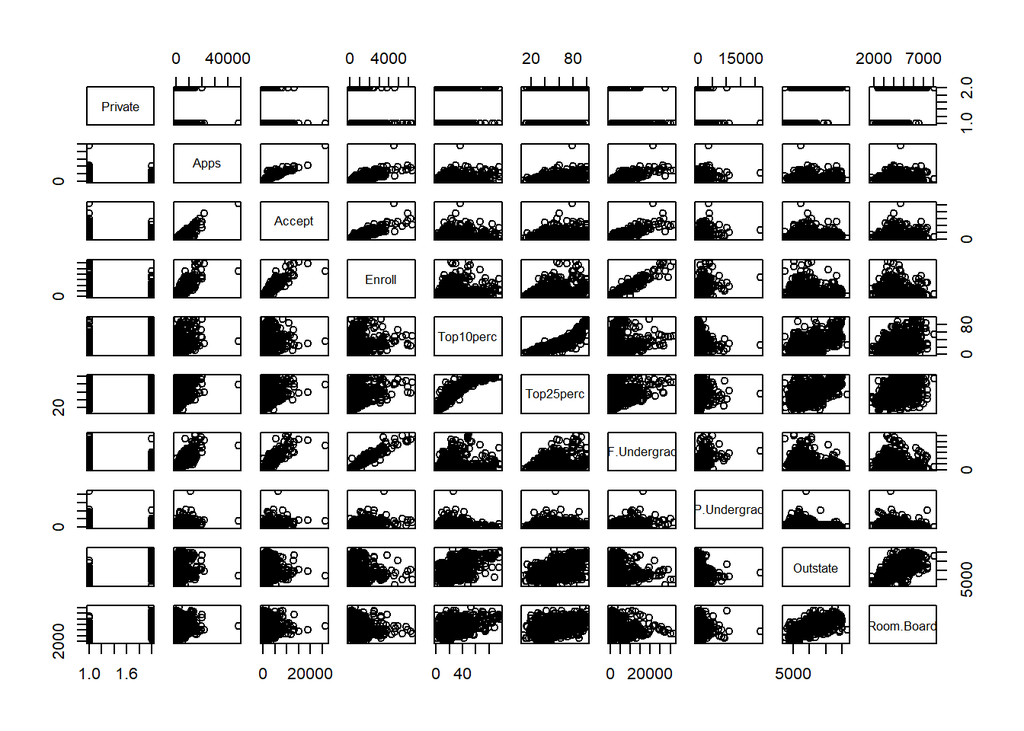

```r
pairs(college[,1:10])
```

**(iii) plot boxplots of outstate versus private**

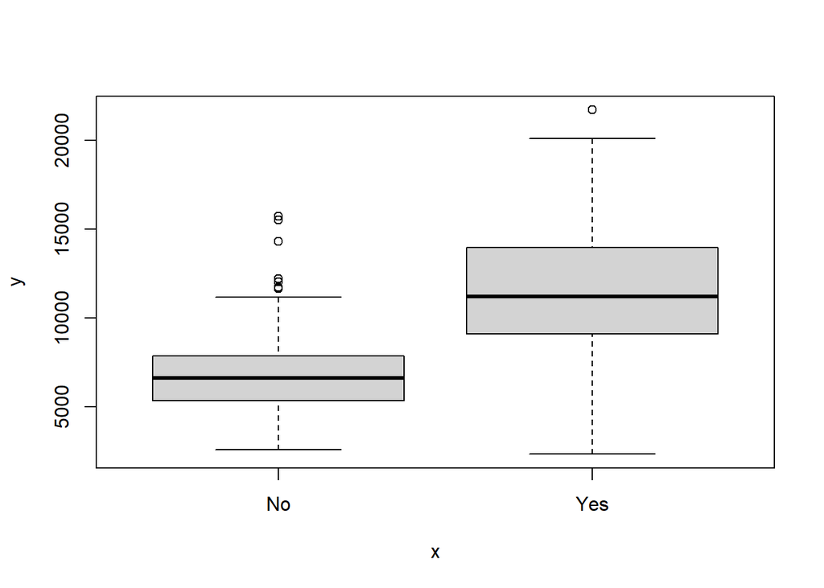

```r
private = as.factor(college[,"Private"])

plot(private, college[,"Outstate"])
```

**(iv) binning Top10perc to create a new variable, Elite, based on the proportion of top 10% students**

```r
Elite = rep("No", nrow(college))
Elite[college[,"Top10perc"] > 50] = "Yes"
Elite = as.factor(Elite)
college = data.frame(college, Elite)

summary(Elite)
```

```
##  No Yes
## 699  78
```

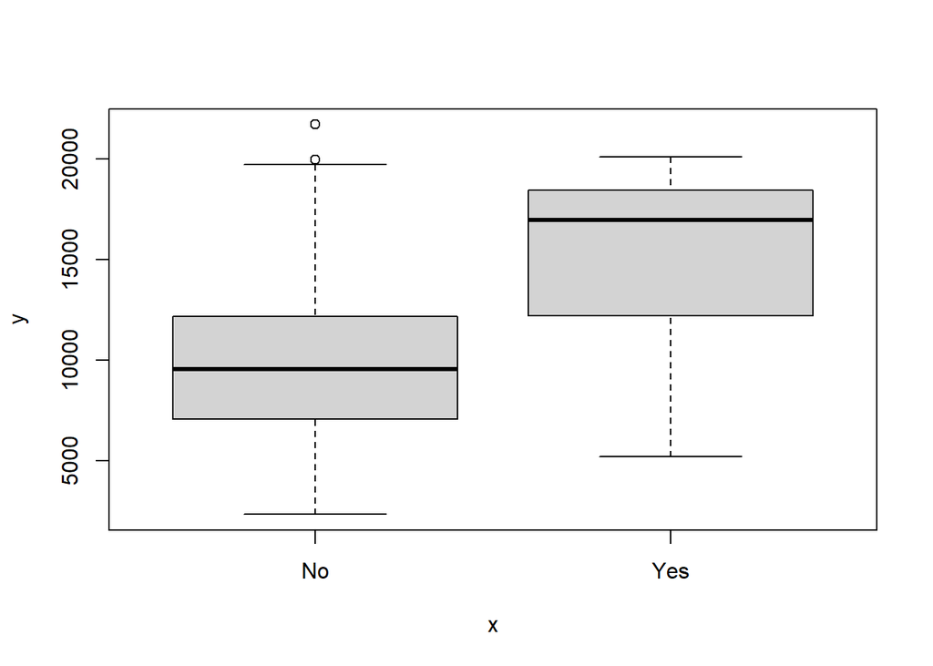

```r
plot(Elite, college[,"Outstate"])
```

**(v) histograms of quantitative variables in college dataset**

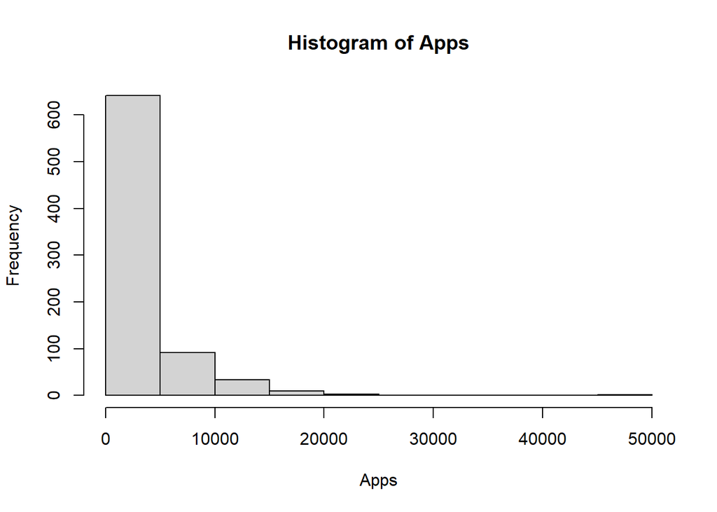

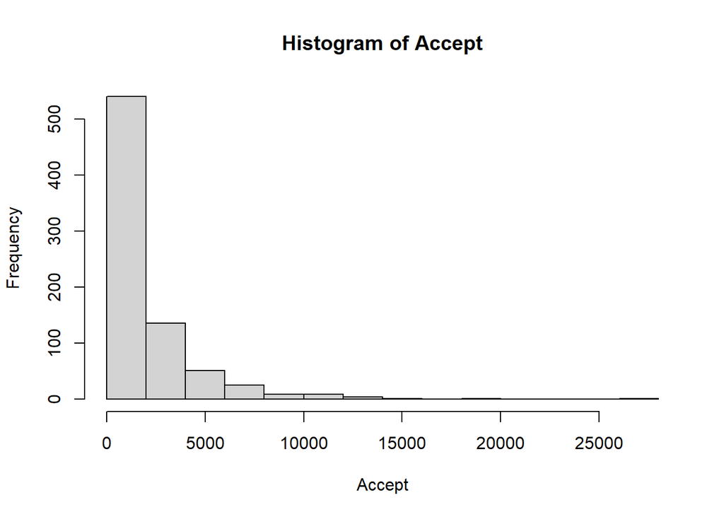

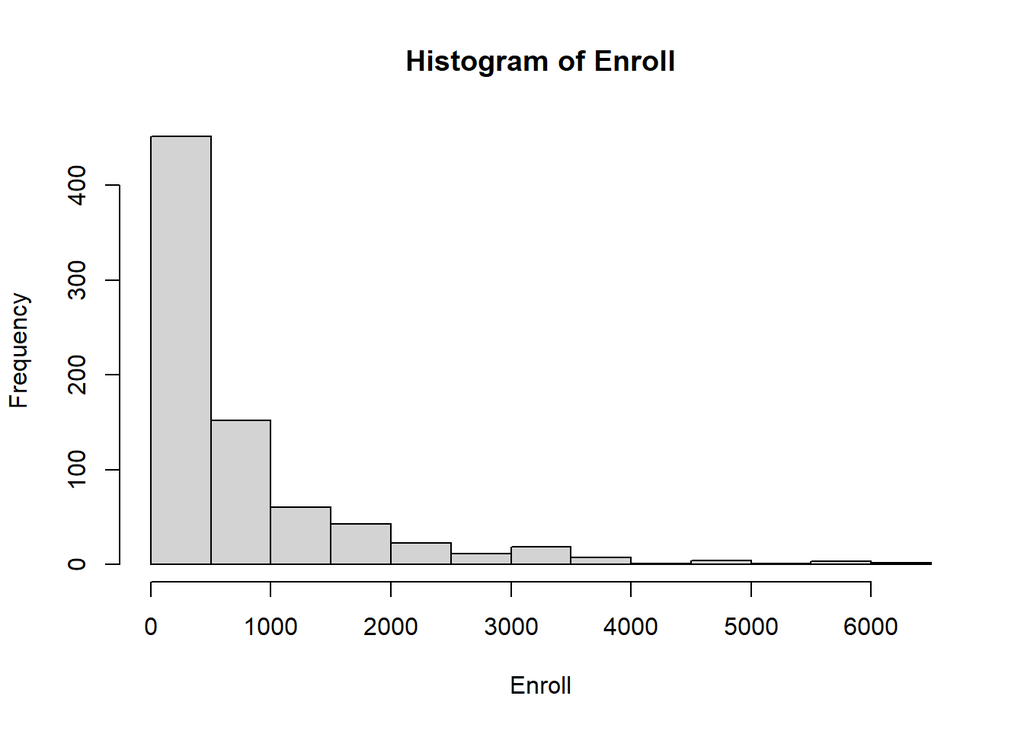

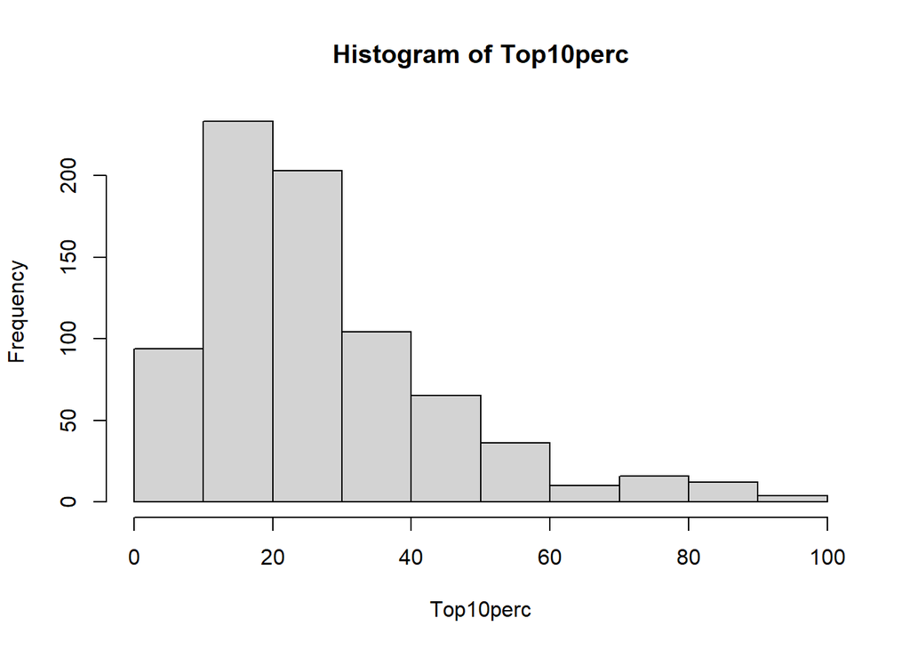

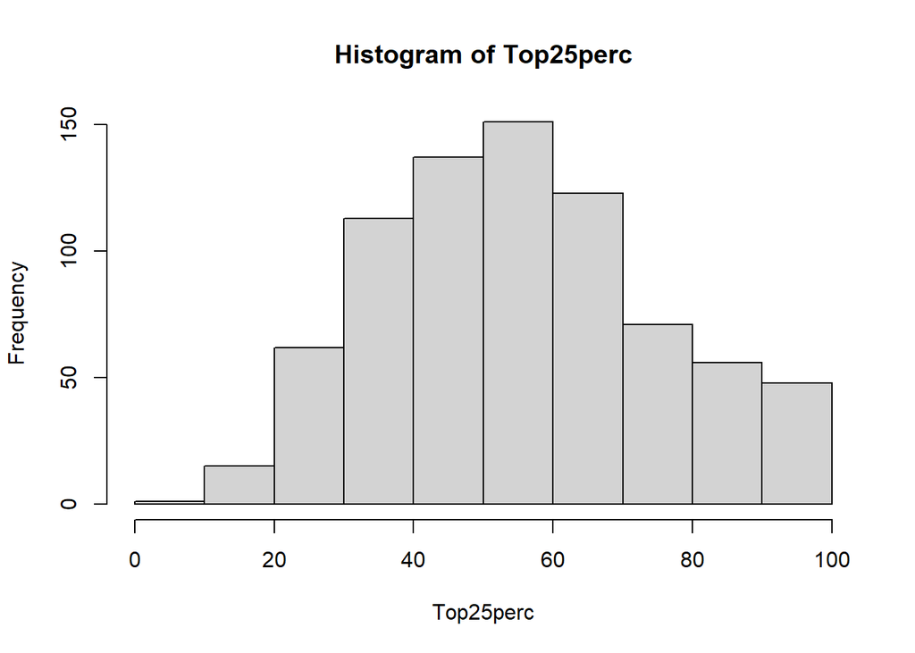

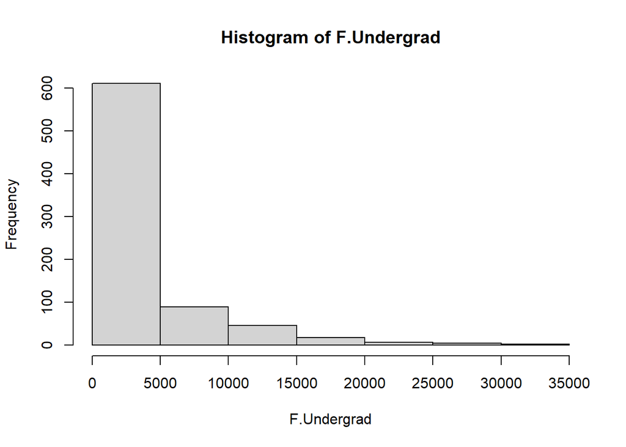

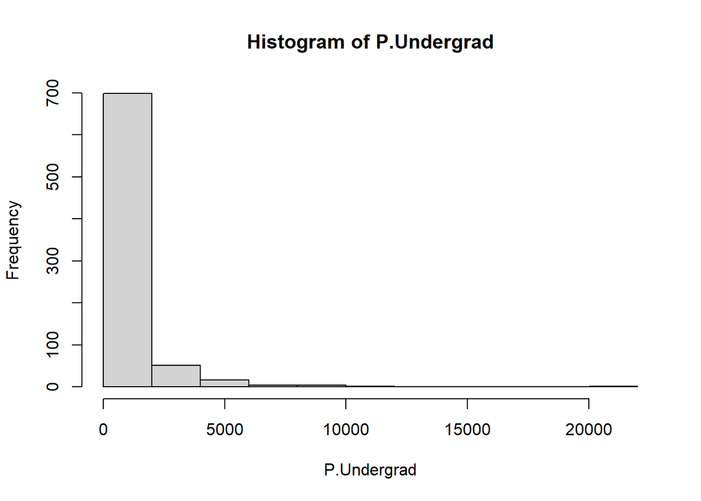

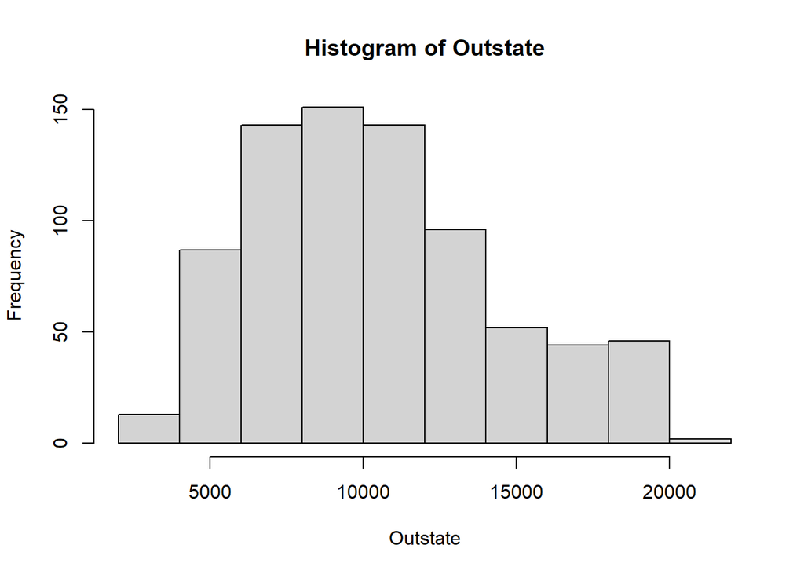

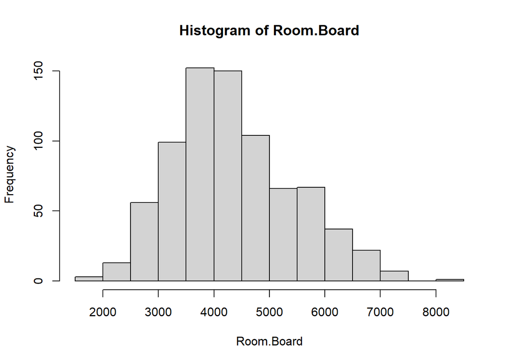

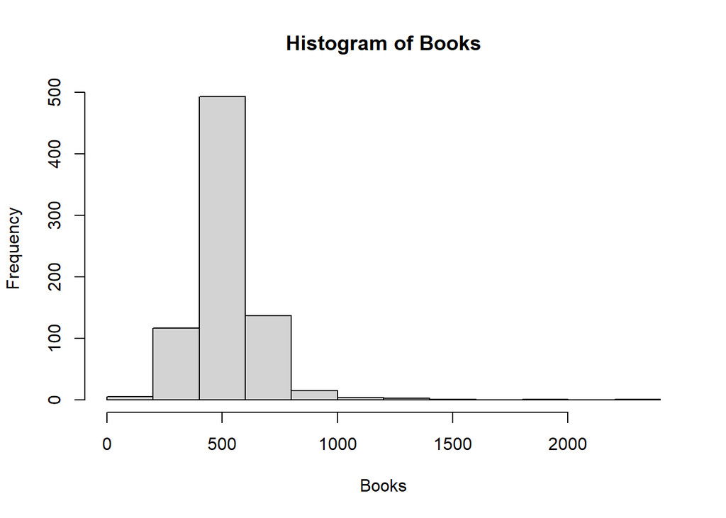

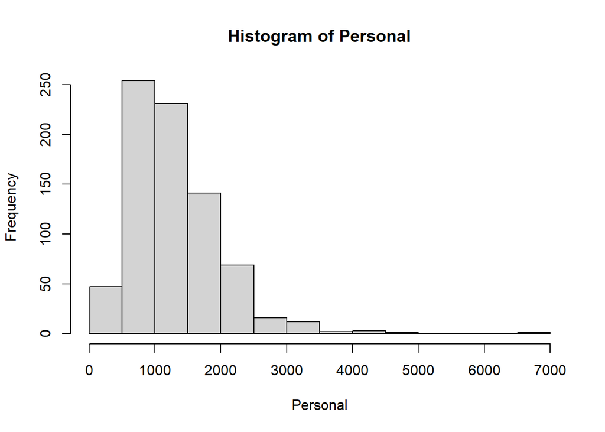

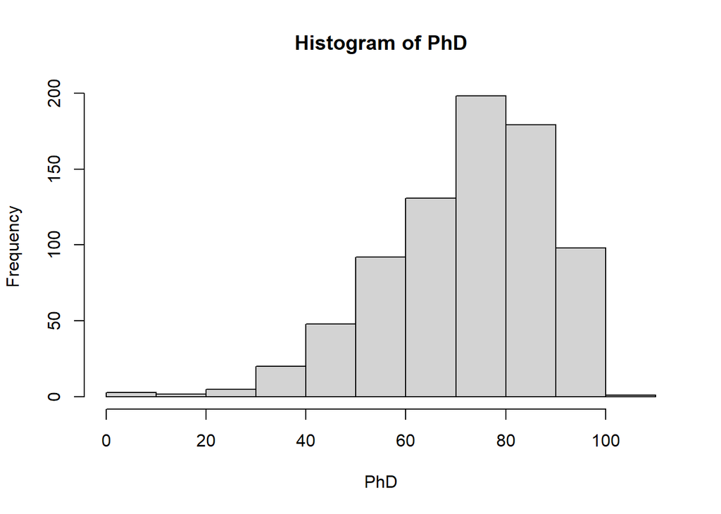

[5 more figures not shown]

```r
college.numeric = college[,sapply(college, is.numeric)]

invisible(lapply(seq(college.numeric),function(x)
  hist(x = college.numeric[[x]], xlab = names(college.numeric)[x], main = paste("Histogram of", names(college.numeric)[x]))))
```

**(vi) data exploration: finding the most above average colleges**

**we will attempt to uncover the best colleges for out of state students using some of the features available**

```r
GV = rep(1, nrow(college))

GV[college[,"Outstate"] < mean(college[,"Outstate"])] = GV[college[,"Outstate"] < mean(college[,"Outstate"])] + 1

GV[college[,"S.F.Ratio"] < mean(college[,"S.F.Ratio"])] = GV[college[,"S.F.Ratio"] < mean(college[,"S.F.Ratio"])] + 1

GV[college[,"Grad.Rate"] > mean(college[,"Grad.Rate"])] = GV[college[,"Grad.Rate"] > mean(college[,"Grad.Rate"])] + 1

GV[college[,"PhD"] > mean(college[,"PhD"])] = GV[college[,"PhD"] > mean(college[,"PhD"])] + 1

GV = as.factor(GV)

college = data.frame(college, GV)

expend = college[college$GV == 5,]$Expend

names = college[college$GV == 5,]$Name

#for (x in rank(-expend))
  #print(names[x])
```

1. “Virginia Tech”
2. “Florida International University”
3. “LaGrange College”
4. “University of Florida”
5. “University of Wisconsin at Madison”
6. “Lenoir-Rhyne College”
7. “New Jersey Institute of Technology”
8. “University of North Carolina at Chapel Hill”
9. “Drury College”
10. “Centenary College of Louisiana”
11. “Bellarmine College”
12. “Emory & Henry College”
13. “Meredith College”

**While these colleges might not have the name recognition of other schools, they are better than average in four key metrics: cheaper outstate tuition, lower student to faculty ratio, higher graduation rate, and a higher number of PhD faculty members. Additionally, these colleges have themselves been ranked by the amount spent per student, with Virginia tech coming in first**

## Section 2.4, page 56-57, question 10

**(a) Load the boston dataset**

```r
library(ISLR2)

boston = Boston

?Boston
```

**A data frame with 506 rows and 13 variables. Rows represent suburbs of Boston, columns represent features of each suburb such as crime rate and nitrogen oxide concentration**

**(b) Pairwise scatterplots**

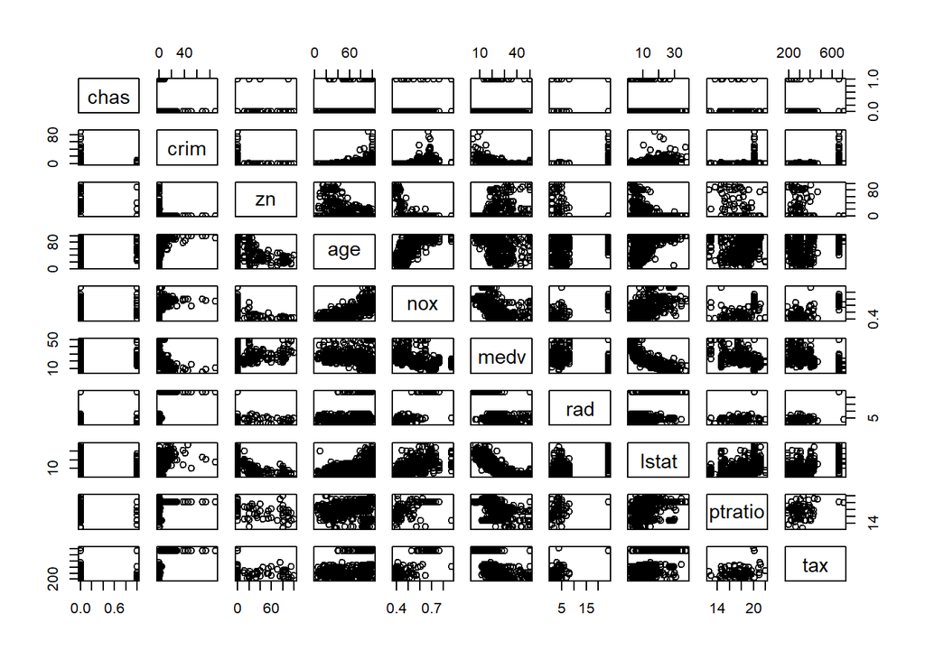

```r
pairs(Boston[,sample(names(Boston),10)])
```

**(C) Are any of the predictors associated with per capita crime rates?**

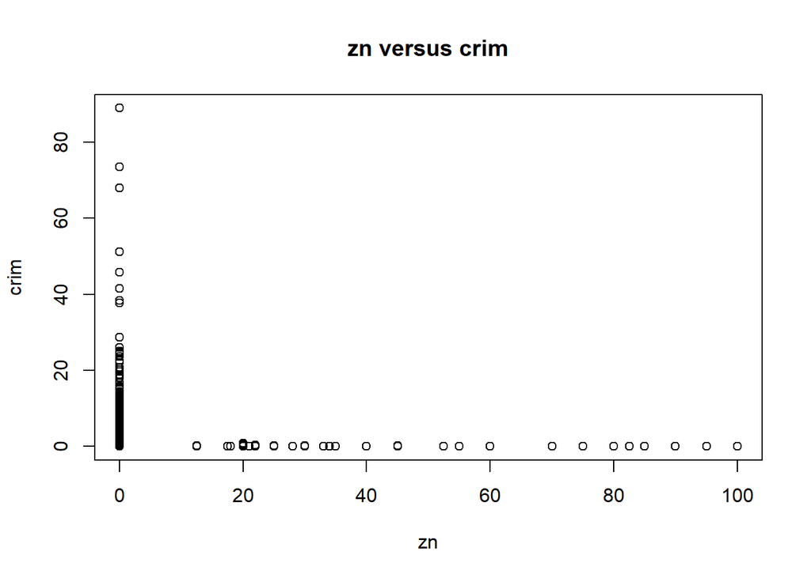

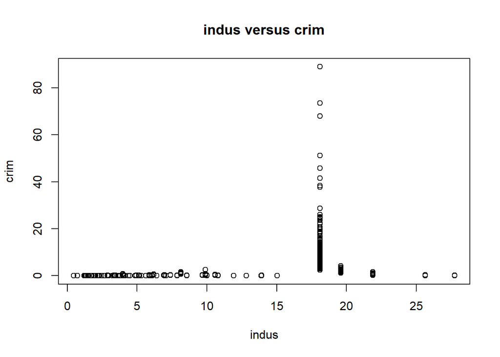

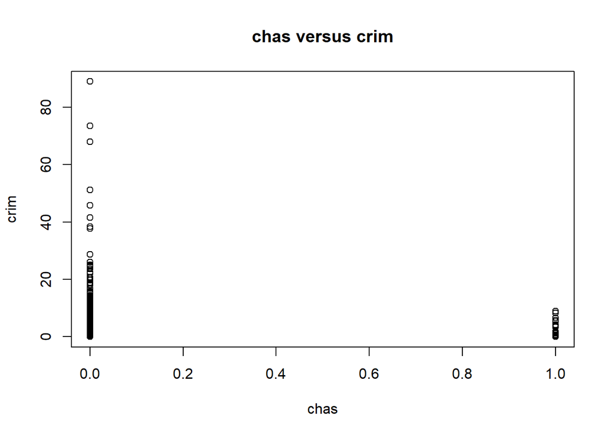

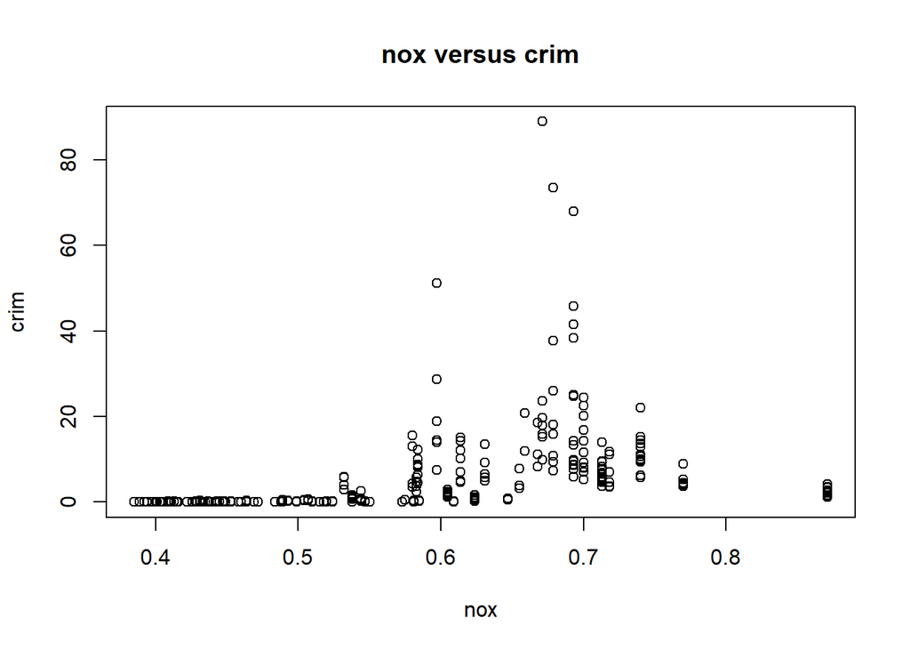

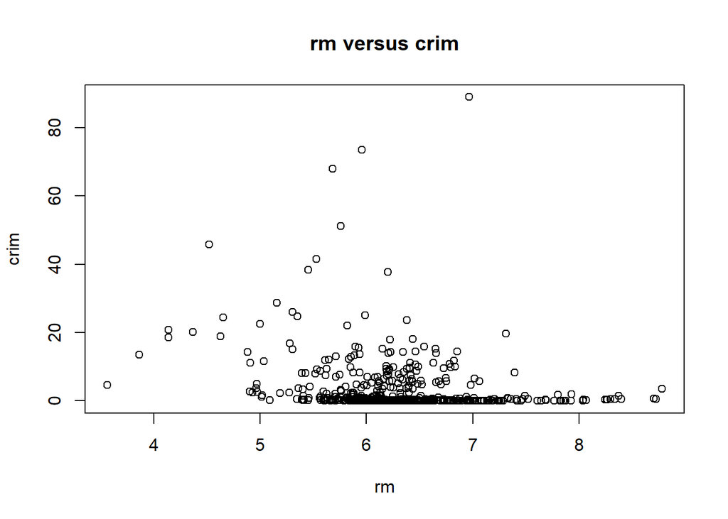

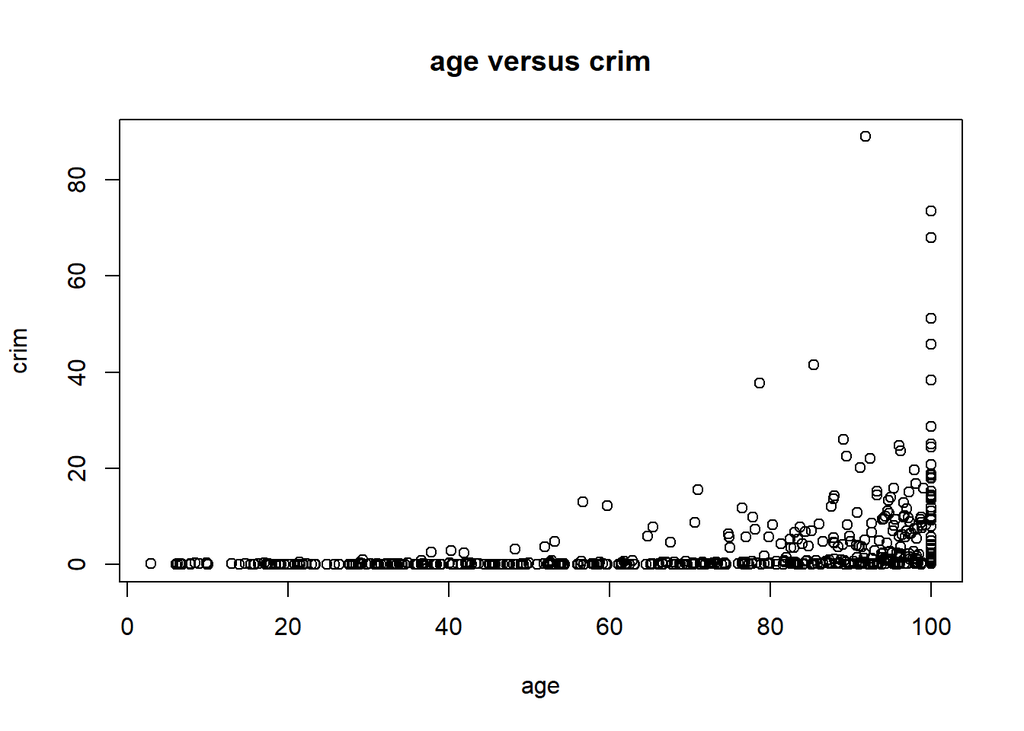

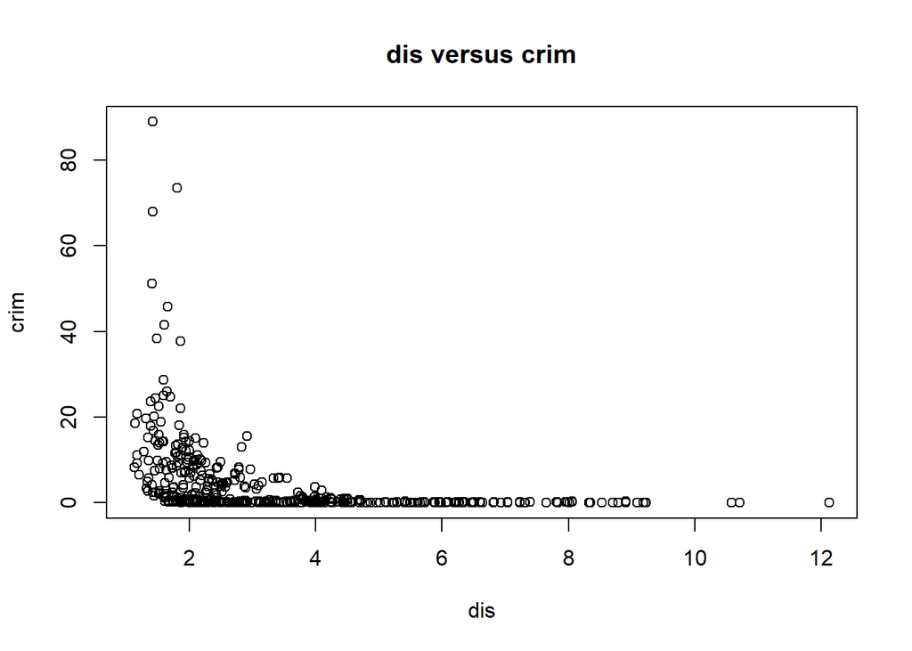

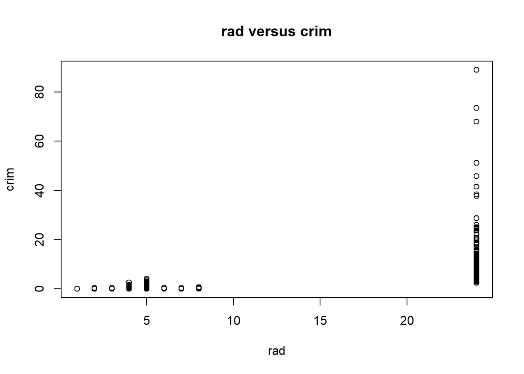

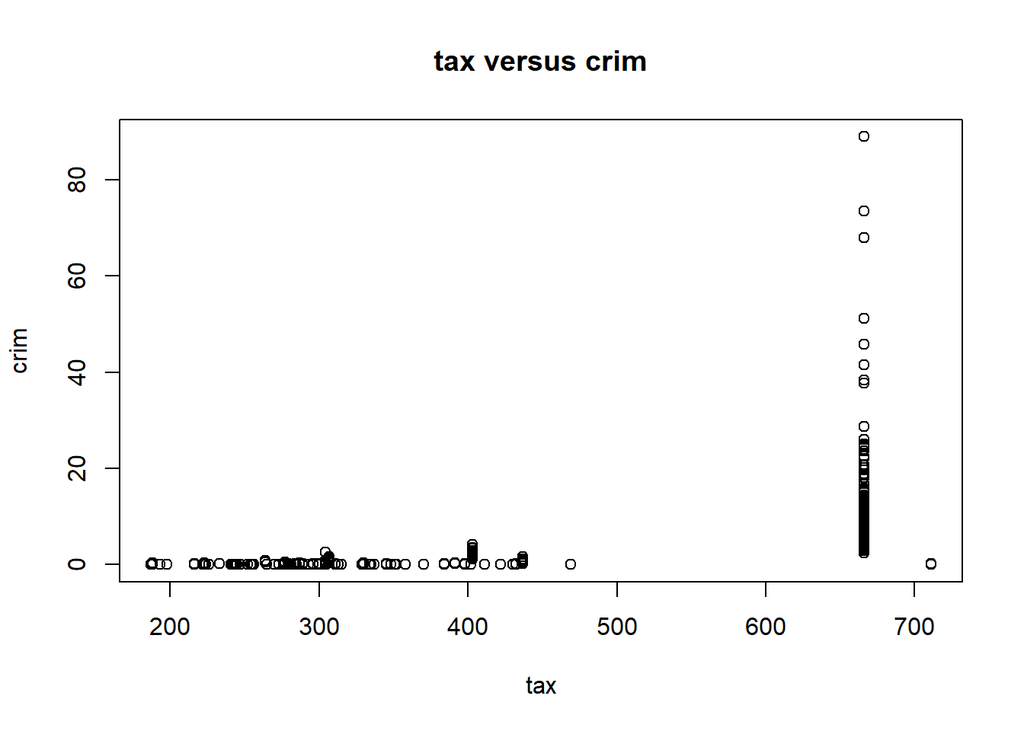

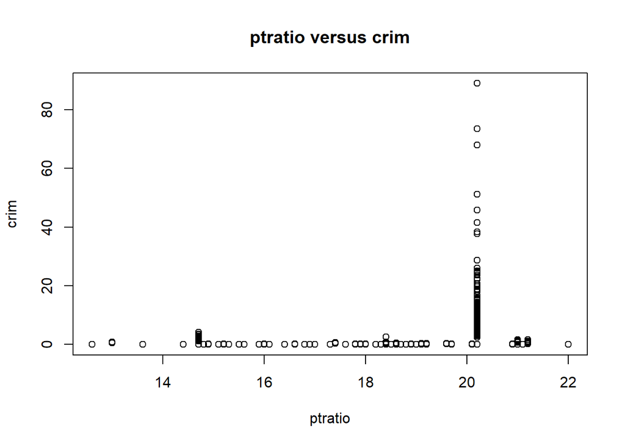

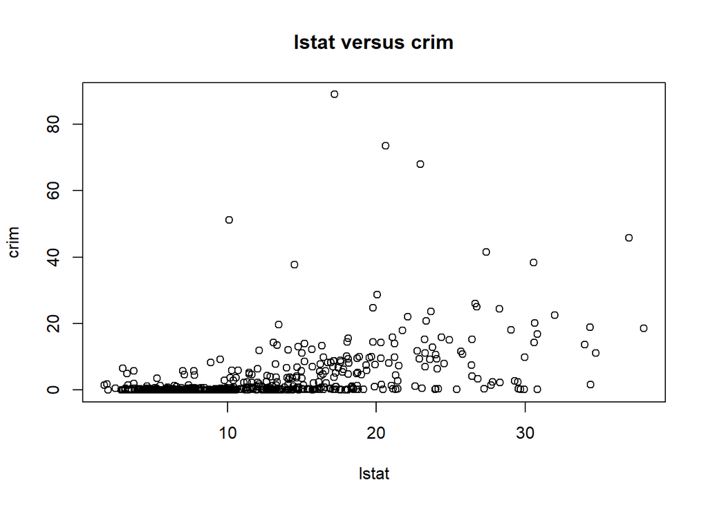

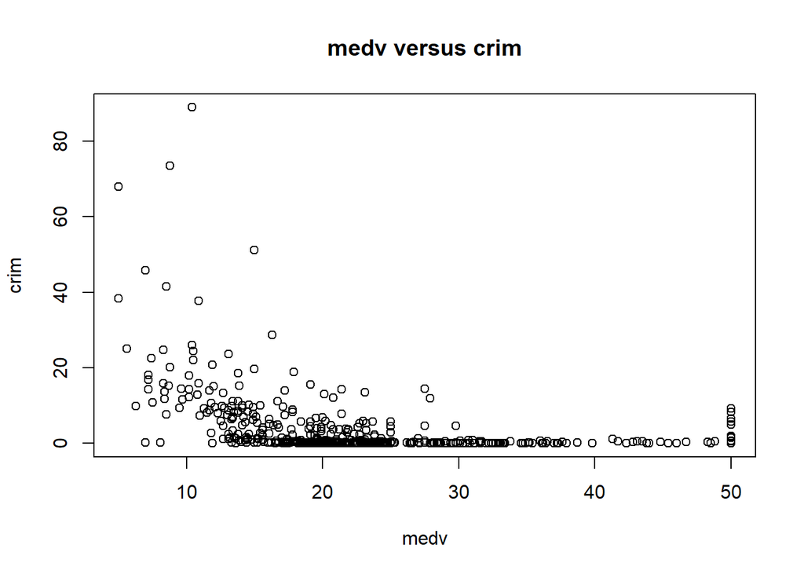

```r
#par(mfrow = c(3,4))

for (n in names(Boston)[-1])
  plot(Boston[,n],Boston[,"crim"],xlab = n, ylab = "crim", main = paste(n,"versus crim"))
```

**Analyzing the relationships between per capita crime rate and the other factors, some interesting observations emerge. Crime rate is noticably higher in denser, industrialized towns as shown by zn and indus, though with indus, towns with a industrialization higher than a certain threshold of non-retail business acres, the crime rate drops dramatically. Older neighborhoods have a higher crime rate, as do neighborhoods closer to Boston. There appears to be a positive correlation between the percentage of lower status individuals and crime rate, as well negative correlation between the median home value and the crime rate.**

**(d) Do any of the census tracts of Boston appear to have particularly high crime rates? Tax rates? Pupil-teacher ratios? Comment on the range of each predictor.**